# Demonstration of Caret for CaRT

JAS

## Classification and Regression Trees using Caret

Yu et al utilized NHANES data from 1999-2004 to predict diabetes and pre-diabetes using Support Vector Machines. We will conduct a similar analysis using the caret package and classification trees. We will use data within the NHANES package in R. For this exercise, you will try to predict Diabetes using similar (although not all) variables. The available data is also slightly different, so you likely won’t get the same answers.

We will restrict the NHANES data to the list of 12 variables below, and partition the data into training and testing using a 70/30 split.

“Age”, “Gender”, “Race1”, “Education”, “HHIncome”, “Weight”, “Height”, “Pulse”, “Diabetes”, “BMI”, “PhysActive”, “Smoke100”

We will build a pipeline to predict diabetes using a classification tree. We will optimize our model using cross-validation to choose hyperparameters in the training data. We will calculate final accuracy in a test set.

```r
library(tidyverse)
library(NHANES)
library(caret)
library(pROC)
```

```r
library(e1071)
library(rpart.plot)
set.seed(100)
#Tidyverse way
#data = NHANES %>% select("Age", "Gender", "Race1", "Education", "HHIncome", "Weight", "Height", "Pulse", "Diabetes", "BMI", "PhysActive", "Smoke100")

data ("NHANES")

keep.var<-names(NHANES) %in% c("Age", "Gender", "Race1", "Education", "HHIncome", "Weight", "Height", "Pulse", "Diabetes", "BMI", "PhysActive", "Smoke100")
NHANES.subset<-NHANES[keep.var]

str(NHANES.subset)
```

```
## tibble [10,000 x 12] (S3: tbl_df/tbl/data.frame)
##  $ Gender    : Factor w/ 2 levels "female","male": 2 2 2 2 1 2 2 1 1 1 ...
##  $ Age       : int [1:10000] 34 34 34 4 49 9 8 45 45 45 ...
##  $ Race1     : Factor w/ 5 levels "Black","Hispanic",..: 4 4 4 5 4 4 4 4 4 4 ...
##  $ Education : Factor w/ 5 levels "8th Grade","9 - 11th Grade",..: 3 3 3 NA 4 NA NA 5 5 5 ...
##  $ HHIncome  : Factor w/ 12 levels " 0-4999"," 5000-9999",..: 6 6 6 5 7 11 9 11 11 11 ...
##  $ Weight    : num [1:10000] 87.4 87.4 87.4 17 86.7 29.8 35.2 75.7 75.7 75.7 ...
##  $ Height    : num [1:10000] 165 165 165 105 168 ...
##  $ BMI       : num [1:10000] 32.2 32.2 32.2 15.3 30.6 ...
##  $ Pulse     : int [1:10000] 70 70 70 NA 86 82 72 62 62 62 ...
##  $ Diabetes  : Factor w/ 2 levels "No","Yes": 1 1 1 1 1 1 1 1 1 1 ...
##  $ PhysActive: Factor w/ 2 levels "No","Yes": 1 1 1 NA 1 NA NA 2 2 2 ...
##  $ Smoke100  : Factor w/ 2 levels "No","Yes": 2 2 2 NA 2 NA NA 1 1 1 ...
```

```r
#Remove missings
NHANES.subset<-na.omit(NHANES.subset)

#Check balance of data ..... uh oh
summary(NHANES.subset$Diabetes)
```

```
##   No  Yes
## 5697  659
```

```r
#Partition data
set.seed(100)
training.indices.2<-NHANES.subset$Diabetes%>% createDataPartition(p=0.7, list=F)
train.data.2<-NHANES.subset[training.indices.2, ]
test.data.2<-NHANES.subset[-training.indices.2, ]

#To use when evaluating
train.noy<-train.data.2[,-10]
test.noy<-test.data.2[,-10]
```

Classification Tree while accounting for imbalanced data

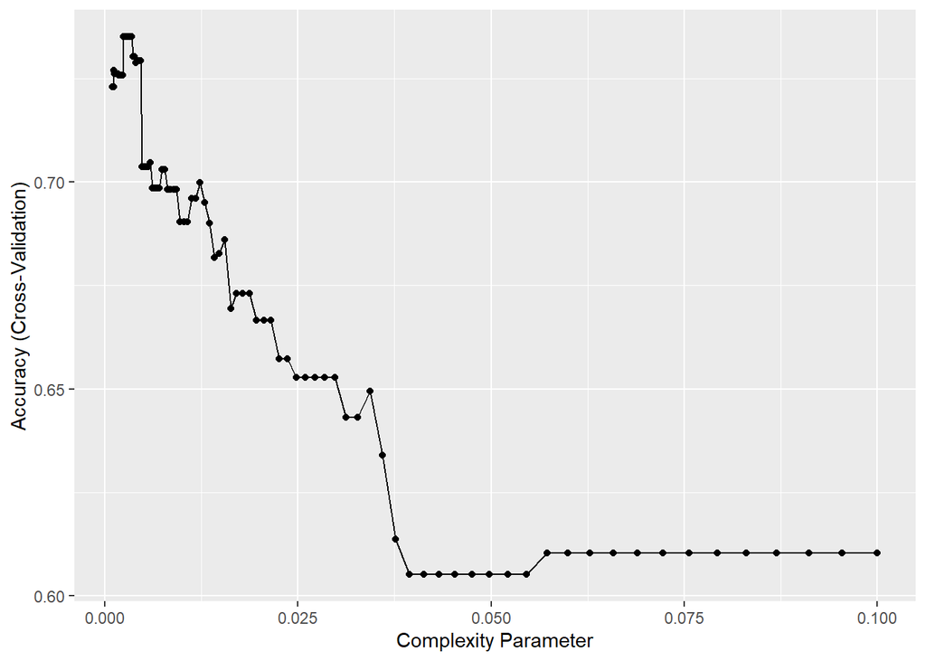

```r
tctrl <- trainControl(method = "cv",
                     number = 10,
                     verboseIter = FALSE,
                     sampling = "down")

cp = 10^seq(-3, -1, length = 100)

 model.tree<- train(Diabetes~.,
        data = train.data.2,
        method = "rpart",
        trControl = tctrl,
        tuneGrid = expand.grid(cp = cp)
  )

 ggplot(model.tree)
```

```r
model.tree$bestTune
```

```
##             cp
## 28 0.003511192
```

```r
#Obtain variable importance metrics
varImp(model.tree)
```

```
## rpart variable importance
##
##   only 20 most important variables shown (out of 37)
##
##                        Overall
## Age                   100.0000
## BMI                    57.8709
## Weight                 47.6118
## Height                 34.5724
## HHIncomemore 99999     25.9005
## Pulse                  24.8751
## Race1White             20.5874
## PhysActiveYes          18.5840
## HHIncome15000-19999     6.8677
## Smoke100Yes             6.3653
## Gendermale              4.6952
## HHIncome10000-14999     4.4714
## EducationCollege Grad   4.4702
## EducationSome College   1.4467
## EducationHigh School    1.2931
## Race1Other              1.2170
## HHIncome65000-74999     1.1438
## HHIncome45000-54999     1.0120
## HHIncome55000-64999     0.7434
## HHIncome75000-99999     0.5832
```

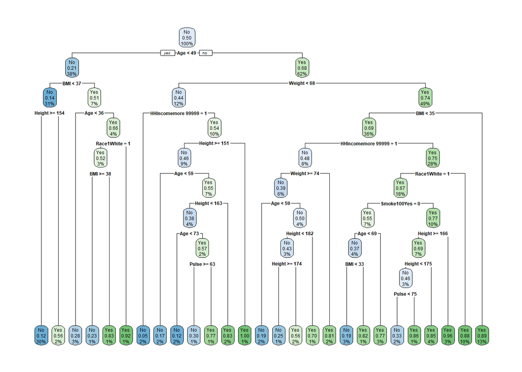

```r
#Visualize the tree
rpart.plot(model.tree$finalModel)
```

```r
#Estimate accuracy in the training data
pred.nhanes<-predict(model.tree, train.noy)
eval.results<-confusionMatrix(pred.nhanes, train.data.2$Diabetes, positive = "Yes")
print(eval.results)
```

```
## Confusion Matrix and Statistics
##
##           Reference
## Prediction   No  Yes
##        No  3038   70
##        Yes  950  392
##
##                Accuracy : 0.7708
##                  95% CI : (0.7581, 0.7831)
##     No Information Rate : 0.8962
##     P-Value [Acc > NIR] : 1
##
##                   Kappa : 0.3313
##
##  Mcnemar's Test P-Value : <2e-16
##
##             Sensitivity : 0.84848
##             Specificity : 0.76179
##          Pos Pred Value : 0.29210
##          Neg Pred Value : 0.97748
##              Prevalence : 0.10382
##          Detection Rate : 0.08809
##    Detection Prevalence : 0.30157
##       Balanced Accuracy : 0.80514
##
##        'Positive' Class : Yes
##
```

```r
#Estimate accuracy in the testing data
pred_diab<-predict(model.tree, test.noy)
pred_diab_prob<- predict(model.tree, test.noy, type = "prob")

tree_results<-confusionMatrix(pred_diab, test.data.2$Diabetes, positive = "Yes")


analysis <- roc(response=test.data.2$Diabetes, predictor=pred_diab_prob[,2])
```

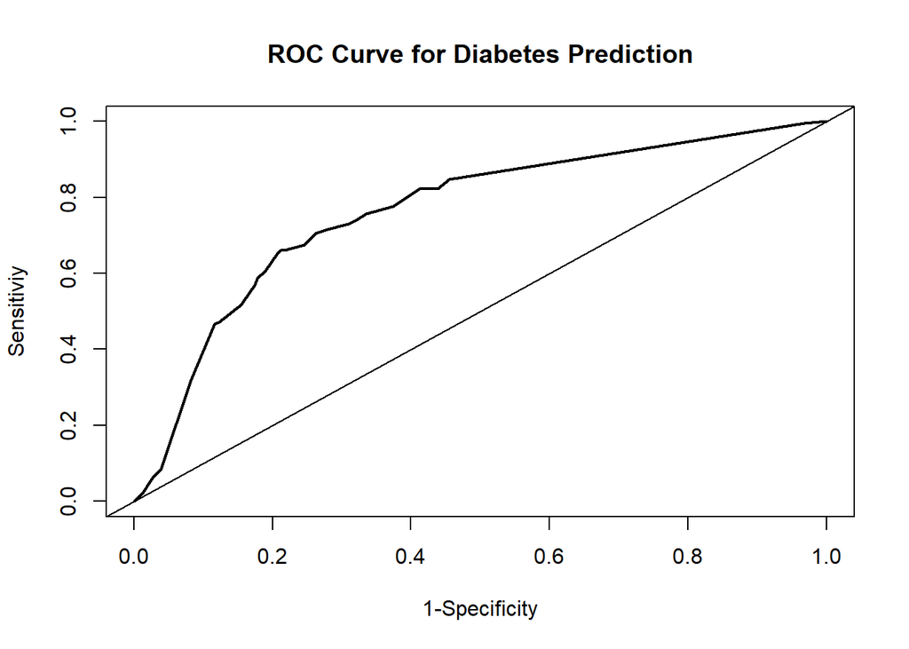

```r
plot(1-analysis$specificities,analysis$sensitivities,type="l",
ylab="Sensitiviy",xlab="1-Specificity",col="black",lwd=2,
main = "ROC Curve for Diabetes Prediction")
abline(a=0,b=1)
```

Don’t account for imbalance in the data

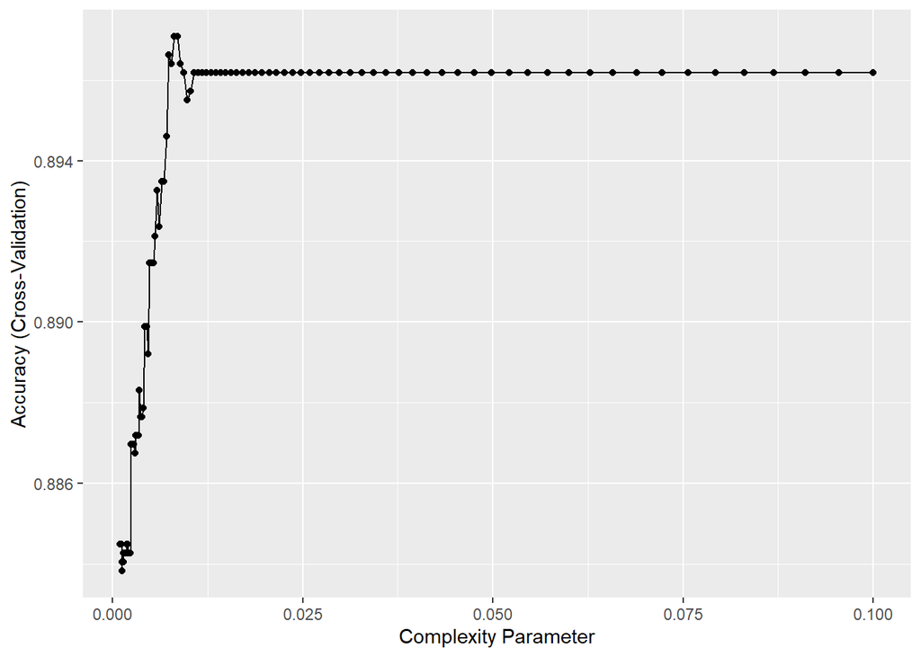

```r
tctrl <- trainControl(method = "cv",
                     number = 10,
                     verboseIter = FALSE)

cp = 10^seq(-3, -1, length = 100)

 model.tree<- train(Diabetes~.,
        data = train.data.2,
        method = "rpart",
        trControl = tctrl,
        tuneGrid = expand.grid(cp = cp)
  )

 ggplot(model.tree)
```

```r
model.tree$bestTune
```

```
##             cp
## 47 0.008497534
```

```r
#Obtain variable importance metrics
varImp(model.tree)
```

```
## rpart variable importance
##
##   only 20 most important variables shown (out of 36)
##
##                       Overall
## Age                   100.000
## BMI                    82.726
## Weight                 64.778
## Race1White             21.804
## PhysActiveYes          21.596
## Height                 16.633
## Pulse                  13.142
## HHIncomemore 99999     10.898
## Gendermale              8.393
## Race1Mexican            7.900
## HHIncome20000-24999     6.412
## HHIncome 5000-9999      5.396
## EducationHigh School    5.272
## HHIncome10000-14999     2.625
## EducationSome College   2.163
## Smoke100Yes             1.744
## HHIncome65000-74999     1.649
## HHIncome45000-54999     1.648
## EducationCollege Grad   1.118
## `HHIncome 5000-9999`    0.000
```

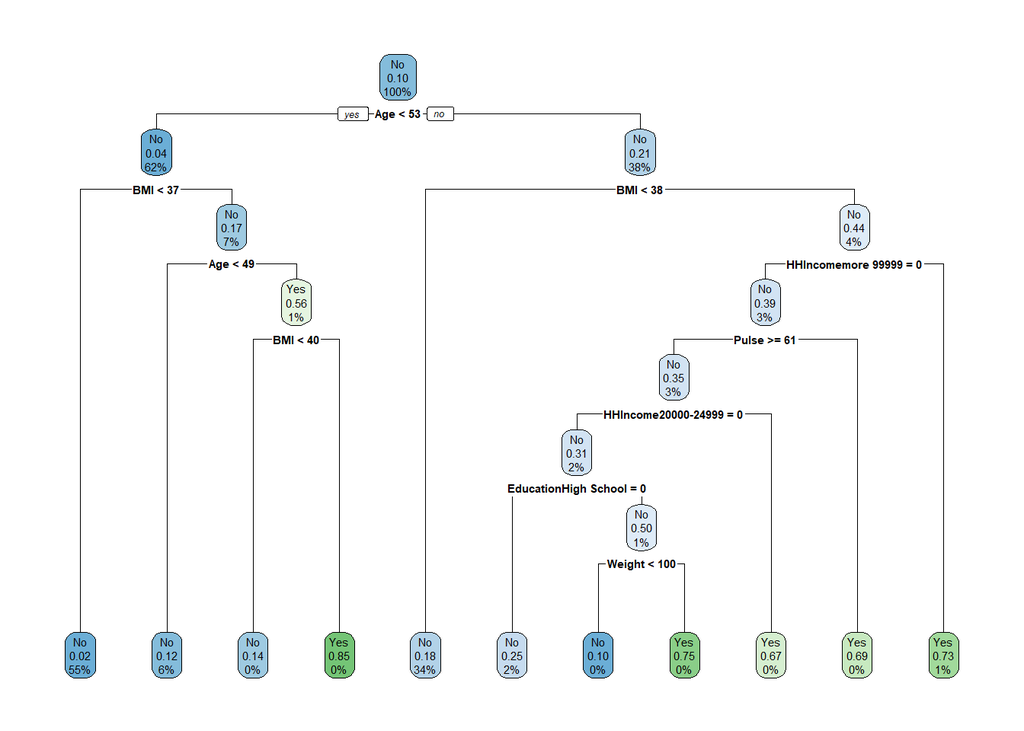

```r
rpart.plot(model.tree$finalModel)
```

```r
pred.nhanes<-predict(model.tree, train.noy)

eval.results<-confusionMatrix(pred.nhanes, train.data.2$Diabetes, positive = "Yes")
print(eval.results)
```

```
## Confusion Matrix and Statistics
##
##           Reference
## Prediction   No  Yes
##        No  3964  393
##        Yes   24   69
##
##                Accuracy : 0.9063
##                  95% CI : (0.8973, 0.9147)
##     No Information Rate : 0.8962
##     P-Value [Acc > NIR] : 0.01346
##
##                   Kappa : 0.2216
##
##  Mcnemar's Test P-Value : < 2e-16
##
##             Sensitivity : 0.14935
##             Specificity : 0.99398
##          Pos Pred Value : 0.74194
##          Neg Pred Value : 0.90980
##              Prevalence : 0.10382
##          Detection Rate : 0.01551
##    Detection Prevalence : 0.02090
##       Balanced Accuracy : 0.57167
##
##        'Positive' Class : Yes
##
```

```r
#Estimate accuracy in the testing data
pred_diab<-predict(model.tree, test.noy)
pred_diab_prob<- predict(model.tree, test.noy, type = "prob")

tree_results<-confusionMatrix(pred_diab, test.data.2$Diabetes, positive = "Yes")
tree_results
```

```
## Confusion Matrix and Statistics
##
##           Reference
## Prediction   No  Yes
##        No  1682  175
##        Yes   27   22
##
##                Accuracy : 0.894
##                  95% CI : (0.8793, 0.9075)
##     No Information Rate : 0.8966
##     P-Value [Acc > NIR] : 0.6635
##
##                   Kappa : 0.1436
##
##  Mcnemar's Test P-Value : <2e-16
##
##             Sensitivity : 0.11168
##             Specificity : 0.98420
##          Pos Pred Value : 0.44898
##          Neg Pred Value : 0.90576
##              Prevalence : 0.10336
##          Detection Rate : 0.01154
##    Detection Prevalence : 0.02571
##       Balanced Accuracy : 0.54794
##
##        'Positive' Class : Yes
##
```

```r
analysis <- roc(response=test.data.2$Diabetes, predictor=pred_diab_prob[,2])
```

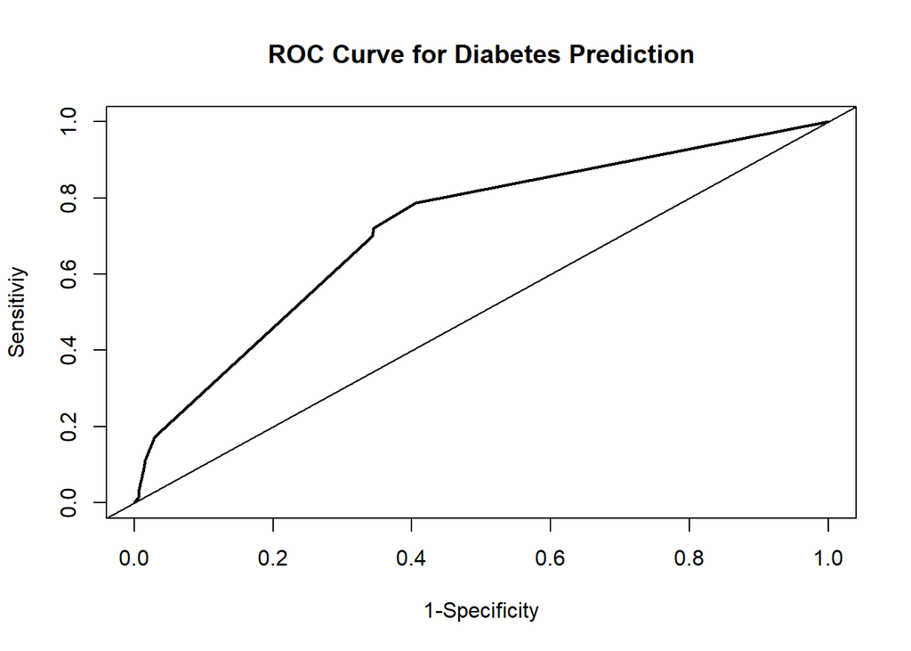

```r
plot(1-analysis$specificities,analysis$sensitivities,type="l",
ylab="Sensitiviy",xlab="1-Specificity",col="black",lwd=2,
main = "ROC Curve for Diabetes Prediction")
abline(a=0,b=1)
```

### Using caret more broadly

```r
names(getModelInfo())
```

```
##   [1] "ada"                 "AdaBag"              "AdaBoost.M1"
##   [4] "adaboost"            "amdai"               "ANFIS"
##   [7] "avNNet"              "awnb"                "awtan"
##  [10] "bag"                 "bagEarth"            "bagEarthGCV"
##  [13] "bagFDA"              "bagFDAGCV"           "bam"
##  [16] "bartMachine"         "bayesglm"            "binda"
##  [19] "blackboost"          "blasso"              "blassoAveraged"
##  [22] "bridge"              "brnn"                "BstLm"
##  [25] "bstSm"               "bstTree"             "C5.0"
##  [28] "C5.0Cost"            "C5.0Rules"           "C5.0Tree"
##  [31] "cforest"             "chaid"               "CSimca"
##  [34] "ctree"               "ctree2"              "cubist"
##  [37] "dda"                 "deepboost"           "DENFIS"
##  [40] "dnn"                 "dwdLinear"           "dwdPoly"
##  [43] "dwdRadial"           "earth"               "elm"
```

[output cut: 65 more lines]

```r
modelLookup("rpart")
```

```
##   model parameter                label forReg forClass probModel
## 1 rpart        cp Complexity Parameter   TRUE     TRUE      TRUE
```

```r
modelLookup("rpart2")
```

```
##    model parameter          label forReg forClass probModel
## 1 rpart2  maxdepth Max Tree Depth   TRUE     TRUE      TRUE
```